# Risk Factor Analysis

## Outcome Variable

**Outcome Variable:** ever_wasted

## Predictor Variables

**Intervention Variable:** meducyrs

**Adjustment Set:**

- arm
- W_mage
- feducyrs
- hhwealth_quart
- W_mhtcm
- W_gagebrth
- W_birthwt
- W_birthlen
- W_nrooms
- W_nchldlt5
- impfloor
- impsan
- safeh20
- delta_W_mage
- delta_feducyrs
- delta_hhwealth_quart
- delta_W_mhtcm
- delta_W_gagebrth
- delta_W_birthwt
- delta_W_birthlen
- delta_W_nrooms
- delta_W_nchldlt5
- delta_impfloor
- delta_impsan
- delta_safeh20

## Stratifying Variables

The analysis was stratified on these variable(s):

- agecat
- studyid
- country

## Data Summary

| agecat | studyid | country | meducyrs | ever_wasted | n_cell | n |
| --- | --- | --- | --- | --- | --- | --- |
| 0-24 months | ki0047075b-MAL-ED | BANGLADESH | Low | 0 | 46 | 213 |
| 0-24 months | ki0047075b-MAL-ED | BANGLADESH | Low | 1 | 24 | 213 |
| 0-24 months | ki0047075b-MAL-ED | BANGLADESH | Medium | 0 | 44 | 213 |
| 0-24 months | ki0047075b-MAL-ED | BANGLADESH | Medium | 1 | 21 | 213 |
| 0-24 months | ki0047075b-MAL-ED | BANGLADESH | High | 0 | 59 | 213 |
| 0-24 months | ki0047075b-MAL-ED | BANGLADESH | High | 1 | 19 | 213 |
| 0-24 months | ki0047075b-MAL-ED | BRAZIL | Low | 0 | 55 | 232 |
| 0-24 months | ki0047075b-MAL-ED | BRAZIL | Low | 1 | 8 | 232 |
| 0-24 months | ki0047075b-MAL-ED | BRAZIL | Medium | 0 | 82 | 232 |
| 0-24 months | ki0047075b-MAL-ED | BRAZIL | Medium | 1 | 8 | 232 |
| 0-24 months | ki0047075b-MAL-ED | BRAZIL | High | 0 | 76 | 232 |
| 0-24 months | ki0047075b-MAL-ED | BRAZIL | High | 1 | 3 | 232 |
| 0-24 months | ki0047075b-MAL-ED | INDIA | Low | 0 | 33 | 220 |
| 0-24 months | ki0047075b-MAL-ED | INDIA | Low | 1 | 43 | 220 |
| 0-24 months | ki0047075b-MAL-ED | INDIA | Medium | 0 | 44 | 220 |
| 0-24 months | ki0047075b-MAL-ED | INDIA | Medium | 1 | 37 | 220 |
| 0-24 months | ki0047075b-MAL-ED | INDIA | High | 0 | 39 | 220 |
| 0-24 months | ki0047075b-MAL-ED | INDIA | High | 1 | 24 | 220 |
| 0-24 months | ki0047075b-MAL-ED | NEPAL | Low | 0 | 69 | 225 |
| 0-24 months | ki0047075b-MAL-ED | NEPAL | Low | 1 | 27 | 225 |
| 0-24 months | ki0047075b-MAL-ED | NEPAL | Medium | 0 | 51 | 225 |
| 0-24 months | ki0047075b-MAL-ED | NEPAL | Medium | 1 | 25 | 225 |
| 0-24 months | ki0047075b-MAL-ED | NEPAL | High | 0 | 40 | 225 |
| 0-24 months | ki0047075b-MAL-ED | NEPAL | High | 1 | 13 | 225 |
| 0-24 months | ki0047075b-MAL-ED | PERU | Low | 0 | 93 | 301 |
| 0-24 months | ki0047075b-MAL-ED | PERU | Low | 1 | 11 | 301 |
| 0-24 months | ki0047075b-MAL-ED | PERU | Medium | 0 | 95 | 301 |
| 0-24 months | ki0047075b-MAL-ED | PERU | Medium | 1 | 12 | 301 |
| 0-24 months | ki0047075b-MAL-ED | PERU | High | 0 | 87 | 301 |
| 0-24 months | ki0047075b-MAL-ED | PERU | High | 1 | 3 | 301 |

[output cut: 438 more lines]

The following strata were considered:

- agecat: 0-24 months, studyid: ki0047075b-MAL-ED, country: BANGLADESH
- agecat: 0-24 months, studyid: ki0047075b-MAL-ED, country: BRAZIL
- agecat: 0-24 months, studyid: ki0047075b-MAL-ED, country: INDIA
- agecat: 0-24 months, studyid: ki0047075b-MAL-ED, country: NEPAL
- agecat: 0-24 months, studyid: ki0047075b-MAL-ED, country: PERU
- agecat: 0-24 months, studyid: ki0047075b-MAL-ED, country: SOUTH AFRICA
- agecat: 0-24 months, studyid: ki0047075b-MAL-ED, country: TANZANIA, UNITED REPUBLIC OF
- agecat: 0-24 months, studyid: ki1000108-CMC-V-BCS-2002, country: INDIA
- agecat: 0-24 months, studyid: ki1000108-IRC, country: INDIA
- agecat: 0-24 months, studyid: ki1000109-EE, country: PAKISTAN
- agecat: 0-24 months, studyid: ki1000304b-SAS-CompFeed, country: INDIA
- agecat: 0-24 months, studyid: ki1000304b-SAS-FoodSuppl, country: INDIA
- agecat: 0-24 months, studyid: ki1017093-NIH-Birth, country: BANGLADESH
- agecat: 0-24 months, studyid: ki1017093b-PROVIDE, country: BANGLADESH
- agecat: 0-24 months, studyid: ki1017093c-NIH-Crypto, country: BANGLADESH
- agecat: 0-24 months, studyid: ki1066203-TanzaniaChild2, country: TANZANIA, UNITED REPUBLIC OF
- agecat: 0-24 months, studyid: ki1112895-Guatemala BSC, country: GUATEMALA
- agecat: 0-24 months, studyid: ki1113344-GMS-Nepal, country: NEPAL
- agecat: 0-24 months, studyid: ki1119695-PROBIT, country: BELARUS
- agecat: 0-24 months, studyid: ki1126311-ZVITAMBO, country: ZIMBABWE
- agecat: 0-24 months, studyid: ki1135781-COHORTS, country: GUATEMALA
- agecat: 0-24 months, studyid: ki1135781-COHORTS, country: INDIA
- agecat: 0-24 months, studyid: ki1135781-COHORTS, country: PHILIPPINES
- agecat: 0-24 months, studyid: ki1148112-LCNI-5, country: MALAWI
- agecat: 0-24 months, studyid: kiGH5241-JiVitA-3, country: BANGLADESH
- agecat: 0-24 months, studyid: kiGH5241-JiVitA-4, country: BANGLADESH
- agecat: 0-6 months, studyid: ki0047075b-MAL-ED, country: BANGLADESH
- agecat: 0-6 months, studyid: ki0047075b-MAL-ED, country: BRAZIL
- agecat: 0-6 months, studyid: ki0047075b-MAL-ED, country: INDIA
- agecat: 0-6 months, studyid: ki0047075b-MAL-ED, country: NEPAL
- agecat: 0-6 months, studyid: ki0047075b-MAL-ED, country: PERU
- agecat: 0-6 months, studyid: ki0047075b-MAL-ED, country: SOUTH AFRICA
- agecat: 0-6 months, studyid: ki0047075b-MAL-ED, country: TANZANIA, UNITED REPUBLIC OF
- agecat: 0-6 months, studyid: ki1000108-CMC-V-BCS-2002, country: INDIA
- agecat: 0-6 months, studyid: ki1000108-IRC, country: INDIA
- agecat: 0-6 months, studyid: ki1000109-EE, country: PAKISTAN
- agecat: 0-6 months, studyid: ki1000304b-SAS-CompFeed, country: INDIA
- agecat: 0-6 months, studyid: ki1000304b-SAS-FoodSuppl, country: INDIA
- agecat: 0-6 months, studyid: ki1017093-NIH-Birth, country: BANGLADESH
- agecat: 0-6 months, studyid: ki1017093b-PROVIDE, country: BANGLADESH
- agecat: 0-6 months, studyid: ki1017093c-NIH-Crypto, country: BANGLADESH
- agecat: 0-6 months, studyid: ki1066203-TanzaniaChild2, country: TANZANIA, UNITED REPUBLIC OF
- agecat: 0-6 months, studyid: ki1112895-Guatemala BSC, country: GUATEMALA
- agecat: 0-6 months, studyid: ki1113344-GMS-Nepal, country: NEPAL
- agecat: 0-6 months, studyid: ki1119695-PROBIT, country: BELARUS
- agecat: 0-6 months, studyid: ki1126311-ZVITAMBO, country: ZIMBABWE
- agecat: 0-6 months, studyid: ki1135781-COHORTS, country: GUATEMALA
- agecat: 0-6 months, studyid: ki1135781-COHORTS, country: INDIA
- agecat: 0-6 months, studyid: ki1135781-COHORTS, country: PHILIPPINES
- agecat: 0-6 months, studyid: ki1148112-LCNI-5, country: MALAWI
- agecat: 0-6 months, studyid: kiGH5241-JiVitA-3, country: BANGLADESH
- agecat: 0-6 months, studyid: kiGH5241-JiVitA-4, country: BANGLADESH
- agecat: 6-24 months, studyid: ki0047075b-MAL-ED, country: BANGLADESH
- agecat: 6-24 months, studyid: ki0047075b-MAL-ED, country: BRAZIL
- agecat: 6-24 months, studyid: ki0047075b-MAL-ED, country: INDIA
- agecat: 6-24 months, studyid: ki0047075b-MAL-ED, country: NEPAL
- agecat: 6-24 months, studyid: ki0047075b-MAL-ED, country: PERU
- agecat: 6-24 months, studyid: ki0047075b-MAL-ED, country: SOUTH AFRICA
- agecat: 6-24 months, studyid: ki0047075b-MAL-ED, country: TANZANIA, UNITED REPUBLIC OF
- agecat: 6-24 months, studyid: ki1000108-CMC-V-BCS-2002, country: INDIA
- agecat: 6-24 months, studyid: ki1000108-IRC, country: INDIA
- agecat: 6-24 months, studyid: ki1000109-EE, country: PAKISTAN
- agecat: 6-24 months, studyid: ki1000304b-SAS-CompFeed, country: INDIA
- agecat: 6-24 months, studyid: ki1000304b-SAS-FoodSuppl, country: INDIA
- agecat: 6-24 months, studyid: ki1017093-NIH-Birth, country: BANGLADESH
- agecat: 6-24 months, studyid: ki1017093b-PROVIDE, country: BANGLADESH
- agecat: 6-24 months, studyid: ki1017093c-NIH-Crypto, country: BANGLADESH
- agecat: 6-24 months, studyid: ki1066203-TanzaniaChild2, country: TANZANIA, UNITED REPUBLIC OF
- agecat: 6-24 months, studyid: ki1112895-Guatemala BSC, country: GUATEMALA
- agecat: 6-24 months, studyid: ki1113344-GMS-Nepal, country: NEPAL
- agecat: 6-24 months, studyid: ki1119695-PROBIT, country: BELARUS
- agecat: 6-24 months, studyid: ki1126311-ZVITAMBO, country: ZIMBABWE
- agecat: 6-24 months, studyid: ki1135781-COHORTS, country: GUATEMALA
- agecat: 6-24 months, studyid: ki1135781-COHORTS, country: INDIA
- agecat: 6-24 months, studyid: ki1135781-COHORTS, country: PHILIPPINES
- agecat: 6-24 months, studyid: ki1148112-LCNI-5, country: MALAWI
- agecat: 6-24 months, studyid: kiGH5241-JiVitA-3, country: BANGLADESH
- agecat: 6-24 months, studyid: kiGH5241-JiVitA-4, country: BANGLADESH

### Dropped Strata

Some strata were dropped due to rare outcomes:

- agecat: 0-24 months, studyid: ki0047075b-MAL-ED, country: BRAZIL
- agecat: 0-24 months, studyid: ki0047075b-MAL-ED, country: PERU
- agecat: 0-24 months, studyid: ki0047075b-MAL-ED, country: TANZANIA, UNITED REPUBLIC OF
- agecat: 0-6 months, studyid: ki0047075b-MAL-ED, country: BRAZIL
- agecat: 0-6 months, studyid: ki0047075b-MAL-ED, country: PERU
- agecat: 0-6 months, studyid: ki0047075b-MAL-ED, country: TANZANIA, UNITED REPUBLIC OF
- agecat: 0-6 months, studyid: ki1000109-EE, country: PAKISTAN
- agecat: 0-6 months, studyid: ki1000304b-SAS-FoodSuppl, country: INDIA
- agecat: 0-6 months, studyid: ki1112895-Guatemala BSC, country: GUATEMALA
- agecat: 0-6 months, studyid: ki1148112-LCNI-5, country: MALAWI
- agecat: 6-24 months, studyid: ki0047075b-MAL-ED, country: BRAZIL
- agecat: 6-24 months, studyid: ki0047075b-MAL-ED, country: PERU
- agecat: 6-24 months, studyid: ki0047075b-MAL-ED, country: TANZANIA, UNITED REPUBLIC OF
- agecat: 6-24 months, studyid: ki1112895-Guatemala BSC, country: GUATEMALA

## Methods Detail

We’re interested in the causal parameters $E[Y_a]$ for all values of $a \in \mathcal{A}$. These parameters represent the mean outcome if, possibly contrary to fact, we intervened to set all units to have $A=a$. Under the randomization and positivity assumptions, these are identified by the statistical parameters $\psi_a=E_W[E_{Y|A,W}(Y|A=a,W)]$. In addition, we’re interested in the mean of $Y$, $E[Y]$ under no intervention (the observed mean). We will estimate these parameters by using SuperLearner to fit the relevant likelihood factors – $E_{Y|A,W}(Y|A=a,W)$ and $p(A=a|W)$, and then updating our likelihood fit using a joint TMLE.

For unadjusted analyses ($W=\{\}$), initial likelihoods were estimated using Lrnr_glm to estimate the simple $E(Y|A)$ and Lrnr_mean to estimate $p(A)$. For adjusted analyses, a small library containing Lrnr_glmnet, Lrnr_xgboost, and Lrnr_mean was used.

Having estimated these parameters, we will then use the delta method to estimate relative risks and attributable risks relative to a prespecified baseline level of $A$.

# Results Detail

## Results Plots

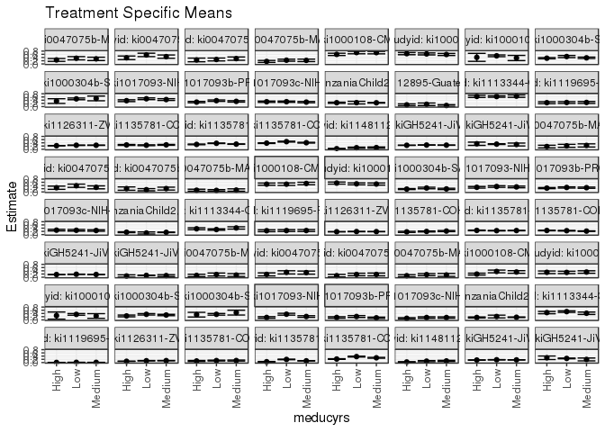

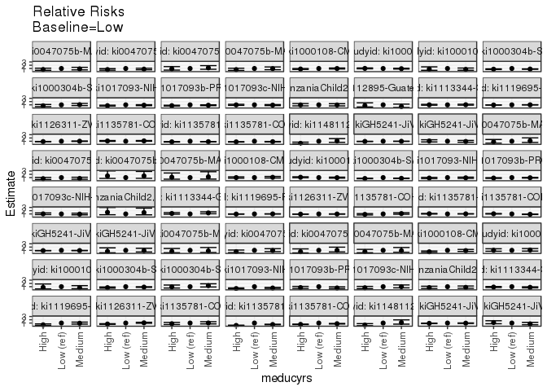

[figure not shown]

[figure not shown]

## Results Table

### Parameter: TSM

| agecat | studyid | country | intervention_level | baseline_level | estimate | ci_lower | ci_upper |
| --- | --- | --- | --- | --- | --- | --- | --- |
| 0-24 months | ki0047075b-MAL-ED | BANGLADESH | Low | NA | 0.3552708 | 0.2544293 | 0.4561123 |
| 0-24 months | ki0047075b-MAL-ED | BANGLADESH | Medium | NA | 0.3157993 | 0.2124126 | 0.4191861 |
| 0-24 months | ki0047075b-MAL-ED | BANGLADESH | High | NA | 0.2489245 | 0.1614432 | 0.3364057 |
| 0-24 months | ki0047075b-MAL-ED | INDIA | Low | NA | 0.5627010 | 0.4575393 | 0.6678626 |
| 0-24 months | ki0047075b-MAL-ED | INDIA | Medium | NA | 0.4546954 | 0.3518065 | 0.5575842 |
| 0-24 months | ki0047075b-MAL-ED | INDIA | High | NA | 0.3817568 | 0.2705408 | 0.4929729 |
| 0-24 months | ki0047075b-MAL-ED | NEPAL | Low | NA | 0.2771204 | 0.1873062 | 0.3669347 |
| 0-24 months | ki0047075b-MAL-ED | NEPAL | Medium | NA | 0.3313831 | 0.2279400 | 0.4348262 |
| 0-24 months | ki0047075b-MAL-ED | NEPAL | High | NA | 0.2494953 | 0.1346224 | 0.3643682 |
| 0-24 months | ki0047075b-MAL-ED | SOUTH AFRICA | Low | NA | 0.2323853 | 0.1704973 | 0.2942734 |
| 0-24 months | ki0047075b-MAL-ED | SOUTH AFRICA | Medium | NA | 0.2226180 | 0.1459577 | 0.2992784 |
| 0-24 months | ki0047075b-MAL-ED | SOUTH AFRICA | High | NA | 0.1559199 | 0.0940190 | 0.2178208 |
| 0-24 months | ki1000108-CMC-V-BCS-2002 | INDIA | Low | NA | 0.7095344 | 0.6318337 | 0.7872352 |
| 0-24 months | ki1000108-CMC-V-BCS-2002 | INDIA | Medium | NA | 0.7048773 | 0.6276721 | 0.7820825 |
| 0-24 months | ki1000108-CMC-V-BCS-2002 | INDIA | High | NA | 0.5950659 | 0.5248306 | 0.6653013 |
| 0-24 months | ki1000108-IRC | INDIA | Low | NA | 0.6249000 | 0.5634700 | 0.6863300 |
| 0-24 months | ki1000108-IRC | INDIA | Medium | NA | 0.5883478 | 0.5233292 | 0.6533663 |
| 0-24 months | ki1000108-IRC | INDIA | High | NA | 0.6412689 | 0.5739669 | 0.7085709 |
| 0-24 months | ki1000109-EE | PAKISTAN | Low | NA | 0.5064649 | 0.4524037 | 0.5605262 |
| 0-24 months | ki1000109-EE | PAKISTAN | Medium | NA | 0.3702608 | 0.2083173 | 0.5322042 |
| 0-24 months | ki1000109-EE | PAKISTAN | High | NA | 0.4101286 | 0.1614583 | 0.6587989 |
| 0-24 months | ki1000304b-SAS-CompFeed | INDIA | Low | NA | 0.4603036 | 0.3949510 | 0.5256561 |
| 0-24 months | ki1000304b-SAS-CompFeed | INDIA | Medium | NA | 0.3809765 | 0.3360790 | 0.4258739 |
| 0-24 months | ki1000304b-SAS-CompFeed | INDIA | High | NA | 0.3584648 | 0.3192502 | 0.3976794 |
| 0-24 months | ki1000304b-SAS-FoodSuppl | INDIA | Low | NA | 0.4816908 | 0.4279187 | 0.5354628 |
| 0-24 months | ki1000304b-SAS-FoodSuppl | INDIA | Medium | NA | 0.5094158 | 0.3628415 | 0.6559901 |
| 0-24 months | ki1000304b-SAS-FoodSuppl | INDIA | High | NA | 0.3449038 | 0.1985571 | 0.4912505 |
| 0-24 months | ki1017093-NIH-Birth | BANGLADESH | Low | NA | 0.4873324 | 0.4342803 | 0.5403844 |
| 0-24 months | ki1017093-NIH-Birth | BANGLADESH | Medium | NA | 0.4369118 | 0.3818208 | 0.4920028 |
| 0-24 months | ki1017093-NIH-Birth | BANGLADESH | High | NA | 0.3688239 | 0.3127427 | 0.4249051 |

[output cut: 162 more lines]

### Parameter: E(Y)

| agecat | studyid | country | intervention_level | baseline_level | estimate | ci_lower | ci_upper |
| --- | --- | --- | --- | --- | --- | --- | --- |
| 0-24 months | ki0047075b-MAL-ED | BANGLADESH | NA | NA | 0.3004695 | 0.2387555 | 0.3621835 |
| 0-24 months | ki0047075b-MAL-ED | INDIA | NA | NA | 0.4727273 | 0.4066048 | 0.5388497 |
| 0-24 months | ki0047075b-MAL-ED | NEPAL | NA | NA | 0.2888889 | 0.2295338 | 0.3482440 |
| 0-24 months | ki0047075b-MAL-ED | SOUTH AFRICA | NA | NA | 0.1955128 | 0.1514355 | 0.2395901 |
| 0-24 months | ki1000108-CMC-V-BCS-2002 | INDIA | NA | NA | 0.6139410 | 0.5644682 | 0.6634139 |
| 0-24 months | ki1000108-IRC | INDIA | NA | NA | 0.6560976 | 0.6100625 | 0.7021326 |
| 0-24 months | ki1000109-EE | PAKISTAN | NA | NA | 0.4907162 | 0.4401862 | 0.5412462 |
| 0-24 months | ki1000304b-SAS-CompFeed | INDIA | NA | NA | 0.4150694 | 0.3581204 | 0.4720184 |
| 0-24 months | ki1000304b-SAS-FoodSuppl | INDIA | NA | NA | 0.4712919 | 0.4233811 | 0.5192026 |
| 0-24 months | ki1017093-NIH-Birth | BANGLADESH | NA | NA | 0.4775641 | 0.4383415 | 0.5167867 |
| 0-24 months | ki1017093b-PROVIDE | BANGLADESH | NA | NA | 0.3514286 | 0.3160364 | 0.3868207 |
| 0-24 months | ki1017093c-NIH-Crypto | BANGLADESH | NA | NA | 0.3311346 | 0.2976093 | 0.3646598 |
| 0-24 months | ki1066203-TanzaniaChild2 | TANZANIA, UNITED REPUBLIC OF | NA | NA | 0.2367980 | 0.2197367 | 0.2538593 |
| 0-24 months | ki1112895-Guatemala BSC | GUATEMALA | NA | NA | 0.1063830 | 0.0703329 | 0.1424331 |
| 0-24 months | ki1113344-GMS-Nepal | NEPAL | NA | NA | 0.5909850 | 0.5515796 | 0.6303903 |
| 0-24 months | ki1119695-PROBIT | BELARUS | NA | NA | 0.2565984 | 0.1993515 | 0.3138454 |
| 0-24 months | ki1126311-ZVITAMBO | ZIMBABWE | NA | NA | 0.2346433 | 0.2276029 | 0.2416837 |
| 0-24 months | ki1135781-COHORTS | GUATEMALA | NA | NA | 0.2564297 | 0.2328823 | 0.2799770 |
| 0-24 months | ki1135781-COHORTS | INDIA | NA | NA | 0.3329911 | 0.3209071 | 0.3450751 |
| 0-24 months | ki1135781-COHORTS | PHILIPPINES | NA | NA | 0.4036125 | 0.3861835 | 0.4210415 |
| 0-24 months | ki1148112-LCNI-5 | MALAWI | NA | NA | 0.0798526 | 0.0612199 | 0.0984853 |
| 0-24 months | kiGH5241-JiVitA-3 | BANGLADESH | NA | NA | 0.2582816 | 0.2518151 | 0.2647481 |
| 0-24 months | kiGH5241-JiVitA-4 | BANGLADESH | NA | NA | 0.3204728 | 0.2971300 | 0.3438156 |
| 0-6 months | ki0047075b-MAL-ED | BANGLADESH | NA | NA | 0.2206573 | 0.1648355 | 0.2764790 |
| 0-6 months | ki0047075b-MAL-ED | INDIA | NA | NA | 0.3136364 | 0.2521871 | 0.3750856 |
| 0-6 months | ki0047075b-MAL-ED | NEPAL | NA | NA | 0.1777778 | 0.1277101 | 0.2278455 |
| 0-6 months | ki0047075b-MAL-ED | SOUTH AFRICA | NA | NA | 0.1025641 | 0.0688457 | 0.1362825 |
| 0-6 months | ki1000108-CMC-V-BCS-2002 | INDIA | NA | NA | 0.5190217 | 0.4679041 | 0.5701394 |
| 0-6 months | ki1000108-IRC | INDIA | NA | NA | 0.5439024 | 0.4956326 | 0.5921723 |
| 0-6 months | ki1000304b-SAS-CompFeed | INDIA | NA | NA | 0.2199336 | 0.1753445 | 0.2645227 |
| 0-6 months | ki1017093-NIH-Birth | BANGLADESH | NA | NA | 0.3569132 | 0.3192325 | 0.3945938 |
| 0-6 months | ki1017093b-PROVIDE | BANGLADESH | NA | NA | 0.2585714 | 0.2261125 | 0.2910304 |
| 0-6 months | ki1017093c-NIH-Crypto | BANGLADESH | NA | NA | 0.2585752 | 0.2273844 | 0.2897660 |
| 0-6 months | ki1066203-TanzaniaChild2 | TANZANIA, UNITED REPUBLIC OF | NA | NA | 0.1395641 | 0.1256566 | 0.1534717 |
| 0-6 months | ki1113344-GMS-Nepal | NEPAL | NA | NA | 0.2954925 | 0.2589234 | 0.3320615 |
| 0-6 months | ki1119695-PROBIT | BELARUS | NA | NA | 0.2497780 | 0.1917926 | 0.3077635 |
| 0-6 months | ki1126311-ZVITAMBO | ZIMBABWE | NA | NA | 0.1809503 | 0.1745333 | 0.1873674 |
| 0-6 months | ki1135781-COHORTS | GUATEMALA | NA | NA | 0.2007612 | 0.1765324 | 0.2249900 |
| 0-6 months | ki1135781-COHORTS | INDIA | NA | NA | 0.2511554 | 0.2398221 | 0.2624886 |
| 0-6 months | ki1135781-COHORTS | PHILIPPINES | NA | NA | 0.2355453 | 0.2204685 | 0.2506222 |
| 0-6 months | kiGH5241-JiVitA-3 | BANGLADESH | NA | NA | 0.1763390 | 0.1707116 | 0.1819665 |
| 0-6 months | kiGH5241-JiVitA-4 | BANGLADESH | NA | NA | 0.1126043 | 0.0962730 | 0.1289355 |
| 6-24 months | ki0047075b-MAL-ED | BANGLADESH | NA | NA | 0.1384615 | 0.0898601 | 0.1870630 |
| 6-24 months | ki0047075b-MAL-ED | INDIA | NA | NA | 0.2657005 | 0.2053824 | 0.3260185 |
| 6-24 months | ki0047075b-MAL-ED | NEPAL | NA | NA | 0.1545455 | 0.1066715 | 0.2024194 |
| 6-24 months | ki0047075b-MAL-ED | SOUTH AFRICA | NA | NA | 0.1389961 | 0.0967835 | 0.1812087 |
| 6-24 months | ki1000108-CMC-V-BCS-2002 | INDIA | NA | NA | 0.2654155 | 0.2205451 | 0.3102860 |
| 6-24 months | ki1000108-IRC | INDIA | NA | NA | 0.3097561 | 0.2649438 | 0.3545684 |
| 6-24 months | ki1000109-EE | PAKISTAN | NA | NA | 0.3306452 | 0.2827744 | 0.3785159 |
| 6-24 months | ki1000304b-SAS-CompFeed | INDIA | NA | NA | 0.3059755 | 0.2638053 | 0.3481458 |
| 6-24 months | ki1000304b-SAS-FoodSuppl | INDIA | NA | NA | 0.3557214 | 0.3088651 | 0.4025777 |
| 6-24 months | ki1017093-NIH-Birth | BANGLADESH | NA | NA | 0.2939002 | 0.2554778 | 0.3323226 |
| 6-24 months | ki1017093b-PROVIDE | BANGLADESH | NA | NA | 0.1609756 | 0.1319065 | 0.1900447 |
| 6-24 months | ki1017093c-NIH-Crypto | BANGLADESH | NA | NA | 0.1315069 | 0.1069744 | 0.1560393 |
| 6-24 months | ki1066203-TanzaniaChild2 | TANZANIA, UNITED REPUBLIC OF | NA | NA | 0.1606166 | 0.1445647 | 0.1766685 |
| 6-24 months | ki1113344-GMS-Nepal | NEPAL | NA | NA | 0.4735945 | 0.4331684 | 0.5140207 |
| 6-24 months | ki1119695-PROBIT | BELARUS | NA | NA | 0.0100615 | 0.0072668 | 0.0128561 |
| 6-24 months | ki1126311-ZVITAMBO | ZIMBABWE | NA | NA | 0.0940163 | 0.0884807 | 0.0995519 |
| 6-24 months | ki1135781-COHORTS | GUATEMALA | NA | NA | 0.1277129 | 0.1088047 | 0.1466210 |
| 6-24 months | ki1135781-COHORTS | INDIA | NA | NA | 0.1266655 | 0.1178579 | 0.1354730 |
| 6-24 months | ki1135781-COHORTS | PHILIPPINES | NA | NA | 0.2666429 | 0.2502871 | 0.2829988 |
| 6-24 months | ki1148112-LCNI-5 | MALAWI | NA | NA | 0.0772105 | 0.0587369 | 0.0956840 |
| 6-24 months | kiGH5241-JiVitA-3 | BANGLADESH | NA | NA | 0.1639905 | 0.1578595 | 0.1701215 |
| 6-24 months | kiGH5241-JiVitA-4 | BANGLADESH | NA | NA | 0.2546959 | 0.2337294 | 0.2756624 |

### Parameter: RR

| agecat | studyid | country | intervention_level | baseline_level | estimate | ci_lower | ci_upper |
| --- | --- | --- | --- | --- | --- | --- | --- |
| 0-24 months | ki0047075b-MAL-ED | BANGLADESH | Low | Low | 1.0000000 | 1.0000000 | 1.0000000 |
| 0-24 months | ki0047075b-MAL-ED | BANGLADESH | Medium | Low | 0.8888975 | 0.5832752 | 1.3546586 |
| 0-24 months | ki0047075b-MAL-ED | BANGLADESH | High | Low | 0.7006612 | 0.4509353 | 1.0886840 |
| 0-24 months | ki0047075b-MAL-ED | INDIA | Low | Low | 1.0000000 | 1.0000000 | 1.0000000 |
| 0-24 months | ki0047075b-MAL-ED | INDIA | Medium | Low | 0.8080586 | 0.6070235 | 1.0756729 |
| 0-24 months | ki0047075b-MAL-ED | INDIA | High | Low | 0.6784365 | 0.4823336 | 0.9542691 |
| 0-24 months | ki0047075b-MAL-ED | NEPAL | Low | Low | 1.0000000 | 1.0000000 | 1.0000000 |
| 0-24 months | ki0047075b-MAL-ED | NEPAL | Medium | Low | 1.1958091 | 0.7650176 | 1.8691850 |
| 0-24 months | ki0047075b-MAL-ED | NEPAL | High | Low | 0.9003137 | 0.5136424 | 1.5780719 |
| 0-24 months | ki0047075b-MAL-ED | SOUTH AFRICA | Low | Low | 1.0000000 | 1.0000000 | 1.0000000 |
| 0-24 months | ki0047075b-MAL-ED | SOUTH AFRICA | Medium | Low | 0.9579694 | 0.6232440 | 1.4724657 |
| 0-24 months | ki0047075b-MAL-ED | SOUTH AFRICA | High | Low | 0.6709541 | 0.4175447 | 1.0781585 |
| 0-24 months | ki1000108-CMC-V-BCS-2002 | INDIA | Low | Low | 1.0000000 | 1.0000000 | 1.0000000 |
| 0-24 months | ki1000108-CMC-V-BCS-2002 | INDIA | Medium | Low | 0.9934363 | 0.8508537 | 1.1599124 |
| 0-24 months | ki1000108-CMC-V-BCS-2002 | INDIA | High | Low | 0.8386709 | 0.7139741 | 0.9851463 |
| 0-24 months | ki1000108-IRC | INDIA | Low | Low | 1.0000000 | 1.0000000 | 1.0000000 |
| 0-24 months | ki1000108-IRC | INDIA | Medium | Low | 0.9415071 | 0.8234415 | 1.0765010 |
| 0-24 months | ki1000108-IRC | INDIA | High | Low | 1.0261945 | 0.9011526 | 1.1685869 |
| 0-24 months | ki1000109-EE | PAKISTAN | Low | Low | 1.0000000 | 1.0000000 | 1.0000000 |
| 0-24 months | ki1000109-EE | PAKISTAN | Medium | Low | 0.7310689 | 0.4662586 | 1.1462776 |
| 0-24 months | ki1000109-EE | PAKISTAN | High | Low | 0.8097868 | 0.4375204 | 1.4987980 |
| 0-24 months | ki1000304b-SAS-CompFeed | INDIA | Low | Low | 1.0000000 | 1.0000000 | 1.0000000 |
| 0-24 months | ki1000304b-SAS-CompFeed | INDIA | Medium | Low | 0.8276635 | 0.7666957 | 0.8934794 |
| 0-24 months | ki1000304b-SAS-CompFeed | INDIA | High | Low | 0.7787574 | 0.6761916 | 0.8968805 |
| 0-24 months | ki1000304b-SAS-FoodSuppl | INDIA | Low | Low | 1.0000000 | 1.0000000 | 1.0000000 |
| 0-24 months | ki1000304b-SAS-FoodSuppl | INDIA | Medium | Low | 1.0575577 | 0.7767336 | 1.4399124 |
| 0-24 months | ki1000304b-SAS-FoodSuppl | INDIA | High | Low | 0.7160274 | 0.4616387 | 1.1105984 |
| 0-24 months | ki1017093-NIH-Birth | BANGLADESH | Low | Low | 1.0000000 | 1.0000000 | 1.0000000 |
| 0-24 months | ki1017093-NIH-Birth | BANGLADESH | Medium | Low | 0.8965376 | 0.7614895 | 1.0555361 |
| 0-24 months | ki1017093-NIH-Birth | BANGLADESH | High | Low | 0.7568221 | 0.6299749 | 0.9092103 |

[output cut: 162 more lines]

### Parameter: PAR

| agecat | studyid | country | intervention_level | baseline_level | estimate | ci_lower | ci_upper |
| --- | --- | --- | --- | --- | --- | --- | --- |
| 0-24 months | ki0047075b-MAL-ED | BANGLADESH | Low | NA | -0.0548013 | -0.1339789 | 0.0243763 |
| 0-24 months | ki0047075b-MAL-ED | INDIA | Low | NA | -0.0899737 | -0.1735789 | -0.0063685 |
| 0-24 months | ki0047075b-MAL-ED | NEPAL | Low | NA | 0.0117685 | -0.0559102 | 0.0794471 |
| 0-24 months | ki0047075b-MAL-ED | SOUTH AFRICA | Low | NA | -0.0368725 | -0.0799820 | 0.0062370 |
| 0-24 months | ki1000108-CMC-V-BCS-2002 | INDIA | Low | NA | -0.0955934 | -0.1628821 | -0.0283047 |
| 0-24 months | ki1000108-IRC | INDIA | Low | NA | 0.0311975 | -0.0137879 | 0.0761830 |
| 0-24 months | ki1000109-EE | PAKISTAN | Low | NA | -0.0157487 | -0.0348693 | 0.0033719 |
| 0-24 months | ki1000304b-SAS-CompFeed | INDIA | Low | NA | -0.0452342 | -0.0705635 | -0.0199048 |
| 0-24 months | ki1000304b-SAS-FoodSuppl | INDIA | Low | NA | -0.0103989 | -0.0347920 | 0.0139942 |
| 0-24 months | ki1017093-NIH-Birth | BANGLADESH | Low | NA | -0.0097683 | -0.0521149 | 0.0325784 |
| 0-24 months | ki1017093b-PROVIDE | BANGLADESH | Low | NA | -0.0185699 | -0.0492093 | 0.0120694 |
| 0-24 months | ki1017093c-NIH-Crypto | BANGLADESH | Low | NA | 0.0255565 | -0.0035848 | 0.0546979 |
| 0-24 months | ki1066203-TanzaniaChild2 | TANZANIA, UNITED REPUBLIC OF | Low | NA | -0.0095124 | -0.0903543 | 0.0713296 |
| 0-24 months | ki1112895-Guatemala BSC | GUATEMALA | Low | NA | -0.0383539 | -0.1031171 | 0.0264094 |
| 0-24 months | ki1113344-GMS-Nepal | NEPAL | Low | NA | -0.0359763 | -0.0624321 | -0.0095205 |
| 0-24 months | ki1119695-PROBIT | BELARUS | Low | NA | 0.0014986 | -0.0042175 | 0.0072147 |
| 0-24 months | ki1126311-ZVITAMBO | ZIMBABWE | Low | NA | -0.0153488 | -0.0248300 | -0.0058675 |
| 0-24 months | ki1135781-COHORTS | GUATEMALA | Low | NA | 0.0057043 | -0.0081338 | 0.0195424 |
| 0-24 months | ki1135781-COHORTS | INDIA | Low | NA | -0.0386488 | -0.0516425 | -0.0256550 |
| 0-24 months | ki1135781-COHORTS | PHILIPPINES | Low | NA | -0.0706040 | -0.0904385 | -0.0507696 |
| 0-24 months | ki1148112-LCNI-5 | MALAWI | Low | NA | -0.0158069 | -0.0433096 | 0.0116958 |
| 0-24 months | kiGH5241-JiVitA-3 | BANGLADESH | Low | NA | -0.0041178 | -0.0109473 | 0.0027118 |
| 0-24 months | kiGH5241-JiVitA-4 | BANGLADESH | Low | NA | -0.0001049 | -0.0048347 | 0.0046248 |
| 0-6 months | ki0047075b-MAL-ED | BANGLADESH | Low | NA | 0.0078233 | -0.0672261 | 0.0828726 |
| 0-6 months | ki0047075b-MAL-ED | INDIA | Low | NA | -0.0712341 | -0.1487792 | 0.0063111 |
| 0-6 months | ki0047075b-MAL-ED | NEPAL | Low | NA | 0.0403348 | -0.0152578 | 0.0959275 |
| 0-6 months | ki0047075b-MAL-ED | SOUTH AFRICA | Low | NA | 0.0079695 | -0.0274042 | 0.0433432 |
| 0-6 months | ki1000108-CMC-V-BCS-2002 | INDIA | Low | NA | 0.0369604 | -0.0297297 | 0.1036504 |
| 0-6 months | ki1000108-IRC | INDIA | Low | NA | 0.0414410 | -0.0007251 | 0.0836071 |
| 0-6 months | ki1000304b-SAS-CompFeed | INDIA | Low | NA | -0.0230987 | -0.0332395 | -0.0129580 |
| 0-6 months | ki1017093-NIH-Birth | BANGLADESH | Low | NA | 0.0221577 | -0.0160814 | 0.0603967 |
| 0-6 months | ki1017093b-PROVIDE | BANGLADESH | Low | NA | -0.0180169 | -0.0384189 | 0.0023851 |
| 0-6 months | ki1017093c-NIH-Crypto | BANGLADESH | Low | NA | -0.0082727 | -0.0478732 | 0.0313279 |
| 0-6 months | ki1066203-TanzaniaChild2 | TANZANIA, UNITED REPUBLIC OF | Low | NA | 0.0420031 | -0.0215270 | 0.1055333 |
| 0-6 months | ki1113344-GMS-Nepal | NEPAL | Low | NA | -0.0182824 | -0.0420829 | 0.0055180 |
| 0-6 months | ki1119695-PROBIT | BELARUS | Low | NA | 0.0024571 | -0.0035052 | 0.0084194 |
| 0-6 months | ki1126311-ZVITAMBO | ZIMBABWE | Low | NA | -0.0059459 | -0.0122396 | 0.0003477 |
| 0-6 months | ki1135781-COHORTS | GUATEMALA | Low | NA | 0.0071813 | -0.0132869 | 0.0276496 |
| 0-6 months | ki1135781-COHORTS | INDIA | Low | NA | 0.0075394 | -0.0017884 | 0.0168671 |
| 0-6 months | ki1135781-COHORTS | PHILIPPINES | Low | NA | -0.0059751 | -0.0190392 | 0.0070890 |
| 0-6 months | kiGH5241-JiVitA-3 | BANGLADESH | Low | NA | -0.0083766 | -0.0136499 | -0.0031032 |
| 0-6 months | kiGH5241-JiVitA-4 | BANGLADESH | Low | NA | -0.0008935 | -0.0041323 | 0.0023453 |
| 6-24 months | ki0047075b-MAL-ED | BANGLADESH | Low | NA | -0.0307692 | -0.1025049 | 0.0409664 |
| 6-24 months | ki0047075b-MAL-ED | INDIA | Low | NA | -0.0380390 | -0.1154472 | 0.0393692 |
| 6-24 months | ki0047075b-MAL-ED | NEPAL | Low | NA | -0.0174976 | -0.0741137 | 0.0391185 |
| 6-24 months | ki0047075b-MAL-ED | SOUTH AFRICA | Low | NA | -0.0237946 | -0.0661931 | 0.0186040 |
| 6-24 months | ki1000108-CMC-V-BCS-2002 | INDIA | Low | NA | -0.0937519 | -0.1633714 | -0.0241323 |
| 6-24 months | ki1000108-IRC | INDIA | Low | NA | 0.0104364 | -0.0492509 | 0.0701236 |
| 6-24 months | ki1000109-EE | PAKISTAN | Low | NA | -0.0119474 | -0.0294135 | 0.0055186 |
| 6-24 months | ki1000304b-SAS-CompFeed | INDIA | Low | NA | -0.0410247 | -0.0687403 | -0.0133091 |
| 6-24 months | ki1000304b-SAS-FoodSuppl | INDIA | Low | NA | 0.0088464 | -0.0152647 | 0.0329575 |
| 6-24 months | ki1017093-NIH-Birth | BANGLADESH | Low | NA | -0.0594070 | -0.1033119 | -0.0155021 |
| 6-24 months | ki1017093b-PROVIDE | BANGLADESH | Low | NA | -0.0479776 | -0.0944716 | -0.0014837 |
| 6-24 months | ki1017093c-NIH-Crypto | BANGLADESH | Low | NA | -0.0162056 | -0.0526251 | 0.0202140 |
| 6-24 months | ki1066203-TanzaniaChild2 | TANZANIA, UNITED REPUBLIC OF | Low | NA | -0.0476525 | -0.1314686 | 0.0361637 |
| 6-24 months | ki1113344-GMS-Nepal | NEPAL | Low | NA | -0.0411758 | -0.0672727 | -0.0150789 |
| 6-24 months | ki1119695-PROBIT | BELARUS | Low | NA | -0.0014143 | -0.0034308 | 0.0006022 |
| 6-24 months | ki1126311-ZVITAMBO | ZIMBABWE | Low | NA | -0.0177503 | -0.0284600 | -0.0070407 |
| 6-24 months | ki1135781-COHORTS | GUATEMALA | Low | NA | 0.0066888 | -0.0117333 | 0.0251108 |
| 6-24 months | ki1135781-COHORTS | INDIA | Low | NA | -0.0658415 | -0.0790683 | -0.0526147 |
| 6-24 months | ki1135781-COHORTS | PHILIPPINES | Low | NA | -0.1029907 | -0.1257388 | -0.0802427 |
| 6-24 months | ki1148112-LCNI-5 | MALAWI | Low | NA | -0.0095601 | -0.0368495 | 0.0177293 |
| 6-24 months | kiGH5241-JiVitA-3 | BANGLADESH | Low | NA | -0.0077442 | -0.0161189 | 0.0006305 |
| 6-24 months | kiGH5241-JiVitA-4 | BANGLADESH | Low | NA | -0.0008644 | -0.0059443 | 0.0042156 |

### Parameter: PAF

| agecat | studyid | country | intervention_level | baseline_level | estimate | ci_lower | ci_upper |
| --- | --- | --- | --- | --- | --- | --- | --- |
| 0-24 months | ki0047075b-MAL-ED | BANGLADESH | Low | NA | -0.1823856 | -0.4804514 | 0.0556692 |
| 0-24 months | ki0047075b-MAL-ED | INDIA | Low | NA | -0.1903289 | -0.3841510 | -0.0236477 |
| 0-24 months | ki0047075b-MAL-ED | NEPAL | Low | NA | 0.0407370 | -0.2247626 | 0.2486826 |
| 0-24 months | ki0047075b-MAL-ED | SOUTH AFRICA | Low | NA | -0.1885938 | -0.4353803 | 0.0157624 |
| 0-24 months | ki1000108-CMC-V-BCS-2002 | INDIA | Low | NA | -0.1557046 | -0.2733766 | -0.0489065 |
| 0-24 months | ki1000108-IRC | INDIA | Low | NA | 0.0475502 | -0.0233106 | 0.1135040 |
| 0-24 months | ki1000109-EE | PAKISTAN | Low | NA | -0.0320934 | -0.0719416 | 0.0062735 |
| 0-24 months | ki1000304b-SAS-CompFeed | INDIA | Low | NA | -0.1089798 | -0.1715348 | -0.0497650 |
| 0-24 months | ki1000304b-SAS-FoodSuppl | INDIA | Low | NA | -0.0220647 | -0.0752057 | 0.0284498 |
| 0-24 months | ki1017093-NIH-Birth | BANGLADESH | Low | NA | -0.0204544 | -0.1133953 | 0.0647284 |
| 0-24 months | ki1017093b-PROVIDE | BANGLADESH | Low | NA | -0.0528413 | -0.1443077 | 0.0313141 |
| 0-24 months | ki1017093c-NIH-Crypto | BANGLADESH | Low | NA | 0.0771787 | -0.0133481 | 0.1596184 |
| 0-24 months | ki1066203-TanzaniaChild2 | TANZANIA, UNITED REPUBLIC OF | Low | NA | -0.0401708 | -0.4443813 | 0.2509213 |
| 0-24 months | ki1112895-Guatemala BSC | GUATEMALA | Low | NA | -0.3605263 | -1.1152923 | 0.1249286 |
| 0-24 months | ki1113344-GMS-Nepal | NEPAL | Low | NA | -0.0608751 | -0.1072254 | -0.0164651 |
| 0-24 months | ki1119695-PROBIT | BELARUS | Low | NA | 0.0058404 | -0.0161665 | 0.0273706 |
| 0-24 months | ki1126311-ZVITAMBO | ZIMBABWE | Low | NA | -0.0654131 | -0.1066474 | -0.0257153 |
| 0-24 months | ki1135781-COHORTS | GUATEMALA | Low | NA | 0.0222451 | -0.0330613 | 0.0745906 |
| 0-24 months | ki1135781-COHORTS | INDIA | Low | NA | -0.1160655 | -0.1562387 | -0.0772881 |
| 0-24 months | ki1135781-COHORTS | PHILIPPINES | Low | NA | -0.1749302 | -0.2264353 | -0.1255882 |
| 0-24 months | ki1148112-LCNI-5 | MALAWI | Low | NA | -0.1979509 | -0.5938669 | 0.0996197 |
| 0-24 months | kiGH5241-JiVitA-3 | BANGLADESH | Low | NA | -0.0159429 | -0.0427800 | 0.0102035 |
| 0-24 months | kiGH5241-JiVitA-4 | BANGLADESH | Low | NA | -0.0003274 | -0.0151949 | 0.0143224 |
| 0-6 months | ki0047075b-MAL-ED | BANGLADESH | Low | NA | 0.0354543 | -0.3723992 | 0.3221008 |
| 0-6 months | ki0047075b-MAL-ED | INDIA | Low | NA | -0.2271231 | -0.5026014 | -0.0021494 |
| 0-6 months | ki0047075b-MAL-ED | NEPAL | Low | NA | 0.2268834 | -0.1509448 | 0.4806795 |
| 0-6 months | ki0047075b-MAL-ED | SOUTH AFRICA | Low | NA | 0.0777027 | -0.3394415 | 0.3649351 |
| 0-6 months | ki1000108-CMC-V-BCS-2002 | INDIA | Low | NA | 0.0712116 | -0.0658334 | 0.1906353 |
| 0-6 months | ki1000108-IRC | INDIA | Low | NA | 0.0761919 | -0.0045139 | 0.1504135 |
| 0-6 months | ki1000304b-SAS-CompFeed | INDIA | Low | NA | -0.1050260 | -0.1526290 | -0.0593889 |
| 0-6 months | ki1017093-NIH-Birth | BANGLADESH | Low | NA | 0.0620814 | -0.0505319 | 0.1626228 |
| 0-6 months | ki1017093b-PROVIDE | BANGLADESH | Low | NA | -0.0696787 | -0.1526854 | 0.0073505 |
| 0-6 months | ki1017093c-NIH-Crypto | BANGLADESH | Low | NA | -0.0319933 | -0.1975193 | 0.1106531 |
| 0-6 months | ki1066203-TanzaniaChild2 | TANZANIA, UNITED REPUBLIC OF | Low | NA | 0.3009595 | -0.3391616 | 0.6351018 |
| 0-6 months | ki1113344-GMS-Nepal | NEPAL | Low | NA | -0.0618710 | -0.1463279 | 0.0163634 |
| 0-6 months | ki1119695-PROBIT | BELARUS | Low | NA | 0.0098371 | -0.0137699 | 0.0328944 |
| 0-6 months | ki1126311-ZVITAMBO | ZIMBABWE | Low | NA | -0.0328594 | -0.0682517 | 0.0013603 |
| 0-6 months | ki1135781-COHORTS | GUATEMALA | Low | NA | 0.0357705 | -0.0712284 | 0.1320819 |
| 0-6 months | ki1135781-COHORTS | INDIA | Low | NA | 0.0300187 | -0.0077154 | 0.0663398 |
| 0-6 months | ki1135781-COHORTS | PHILIPPINES | Low | NA | -0.0253671 | -0.0825174 | 0.0287661 |
| 0-6 months | kiGH5241-JiVitA-3 | BANGLADESH | Low | NA | -0.0475027 | -0.0779761 | -0.0178907 |
| 0-6 months | kiGH5241-JiVitA-4 | BANGLADESH | Low | NA | -0.0079352 | -0.0370102 | 0.0203247 |
| 6-24 months | ki0047075b-MAL-ED | BANGLADESH | Low | NA | -0.2222222 | -0.8619721 | 0.1977177 |
| 6-24 months | ki0047075b-MAL-ED | INDIA | Low | NA | -0.1431649 | -0.4755176 | 0.1143270 |
| 6-24 months | ki0047075b-MAL-ED | NEPAL | Low | NA | -0.1132195 | -0.5456457 | 0.1982266 |
| 6-24 months | ki0047075b-MAL-ED | SOUTH AFRICA | Low | NA | -0.1711886 | -0.5160436 | 0.0952221 |
| 6-24 months | ki1000108-CMC-V-BCS-2002 | INDIA | Low | NA | -0.3532267 | -0.6478796 | -0.1112598 |
| 6-24 months | ki1000108-IRC | INDIA | Low | NA | 0.0336922 | -0.1795445 | 0.2083802 |
| 6-24 months | ki1000109-EE | PAKISTAN | Low | NA | -0.0361337 | -0.0903341 | 0.0153724 |
| 6-24 months | ki1000304b-SAS-CompFeed | INDIA | Low | NA | -0.1340783 | -0.2355252 | -0.0409611 |
| 6-24 months | ki1000304b-SAS-FoodSuppl | INDIA | Low | NA | 0.0248689 | -0.0453297 | 0.0903533 |
| 6-24 months | ki1017093-NIH-Birth | BANGLADESH | Low | NA | -0.2021332 | -0.3645633 | -0.0590379 |
| 6-24 months | ki1017093b-PROVIDE | BANGLADESH | Low | NA | -0.2980430 | -0.6163095 | -0.0424461 |
| 6-24 months | ki1017093c-NIH-Crypto | BANGLADESH | Low | NA | -0.1232298 | -0.4362839 | 0.1215907 |
| 6-24 months | ki1066203-TanzaniaChild2 | TANZANIA, UNITED REPUBLIC OF | Low | NA | -0.2966846 | -0.9397229 | 0.1331798 |
| 6-24 months | ki1113344-GMS-Nepal | NEPAL | Low | NA | -0.0869432 | -0.1444684 | -0.0323094 |
| 6-24 months | ki1119695-PROBIT | BELARUS | Low | NA | -0.1405648 | -0.3549399 | 0.0398924 |
| 6-24 months | ki1126311-ZVITAMBO | ZIMBABWE | Low | NA | -0.1888008 | -0.3090547 | -0.0795937 |
| 6-24 months | ki1135781-COHORTS | GUATEMALA | Low | NA | 0.0523734 | -0.1030803 | 0.1859195 |
| 6-24 months | ki1135781-COHORTS | INDIA | Low | NA | -0.5198064 | -0.6273544 | -0.4193660 |
| 6-24 months | ki1135781-COHORTS | PHILIPPINES | Low | NA | -0.3862497 | -0.4786634 | -0.2996116 |
| 6-24 months | ki1148112-LCNI-5 | MALAWI | Low | NA | -0.1238191 | -0.5366825 | 0.1781195 |
| 6-24 months | kiGH5241-JiVitA-3 | BANGLADESH | Low | NA | -0.0472233 | -0.0998070 | 0.0028463 |
| 6-24 months | kiGH5241-JiVitA-4 | BANGLADESH | Low | NA | -0.0033937 | -0.0235261 | 0.0163427 |